# RPart

Lauren Cappiello

# Recursive Partioning

In this lab, we will work on applying recursive partitioning (tree) models; identify and assess when a model might be overfitting; and assess and compare different models.

We will start with simulated data.

```r
# The rpart package will allow us to create tree models.
library(rpart)
set.seed(0)
```

```r
n = 100
x = seq(n)
true_model = function(x){
    # Piecewise constant
    out = rep(2, length.out = length(x))
    out[x < 50] = 4
    out
}
y = true_model(x) + rnorm(n)

d = data.frame(x = x, y = y)
```

## Building Models

Obviously the true model isn’t linear, but let’s see what happens when we create a linear regression model with these data:

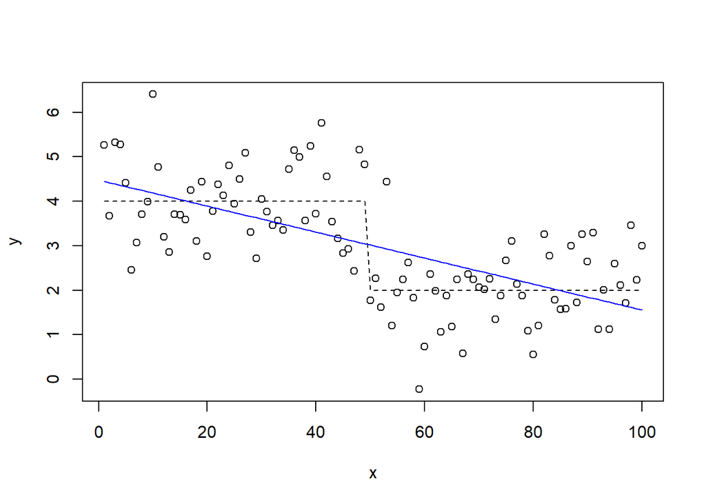

```r
fit_lm = lm(y ~ x, data = d)

plot(x, y)
lines(x, true_model(x), lty = 2)
lines(x, predict(fit_lm), col = "blue")
```

Now let’s try with the recursive partitioning. We should check out the help file before we get started.

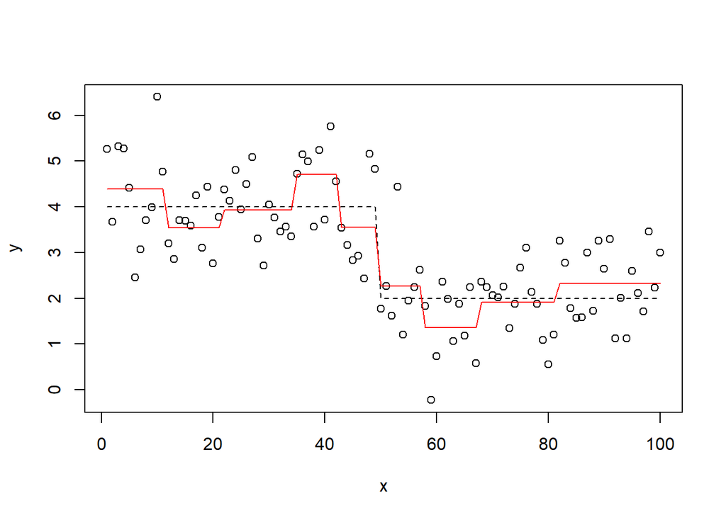

```r
# Use the defaults:
fit_rpart = rpart(y ~ x, data = d)

plot(x, y)
lines(x, true_model(x), lty = 2)
lines(x, predict(fit_rpart), col = "red")
```

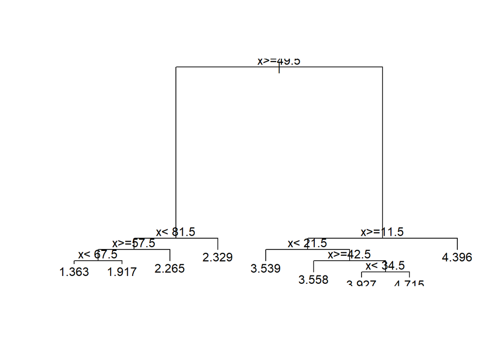

```r
plot(fit_rpart)
text(fit_rpart)
```

Did we capture the truth? It’s not **terrible**, but it’s not good either. To work on this, `rpart` has “tuning parameters” that we can adjust in order to adjust the model to better fit the data.

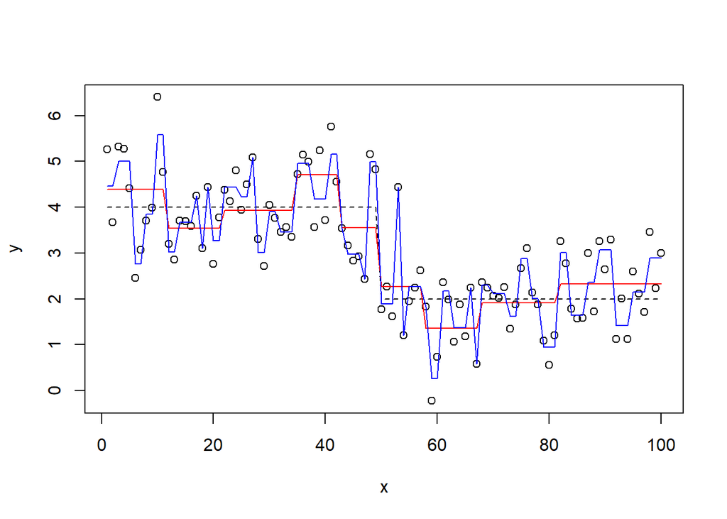

```r
fit_overfit = rpart(y ~ x, data = d, minsplit = 4, cp = 0.0001)

plot(x, y)
lines(x, true_model(x), lty = 2)
lines(x, predict(fit_rpart), col = "red")
lines(x, predict(fit_overfit), col = "blue")
```

This is doing a really good job fitting the **data**, but it’s a terrible fit to the underlying model (and would therefore be a poor fit if we tried to use it to predict $y$ for new values of $x$)! This is a case of *overfitting*.

We want our models to be *parsimonious*, which is sort of like “conservative”. Basically, we want the simplest model that reasonably explains the data; you can think of it as finding a good balance between simplicity and usefulness.

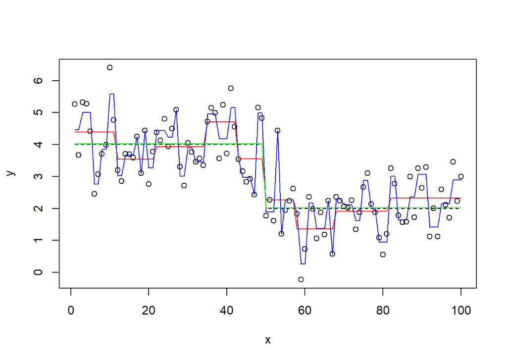

```r
fit_parsimonious = rpart(y ~ x, data = d, minbucket = 30)

plot(x, y)
lines(x, true_model(x), lty = 2)
lines(x, predict(fit_rpart), col = "red")
lines(x, predict(fit_overfit), col = "blue")
lines(x, predict(fit_parsimonious), col = "green")
```

## Evaluating Models

Next, we generate new $y$ data from the true model (and add some random variation).

```r
d2 = data.frame(x, truth = true_model(x))
d2$y = d2$truth + rnorm(n)
```

One way to examine how well the model worked for making new predictions is to examine the mean squared error for each model. For the original model,

```r
error = predict(fit_rpart, d2) - d2$y
mean(error^2)
```

```
## [1] 1.044938
```

Does the best model minimize or maximize MSE?

Next, we will find the MSE for all of the models - the regression, the original rpart model, the overfitted model, and the idealized parsimonious model.

```r
models = list(fit_lm, fit_rpart, fit_overfit, fit_parsimonious)
names(models) = c("linear", "default", "overfit", "parsimonious")

mse = function(fit, data = d2, out = data$y){
  error = predict(fit, data) - out
  mean(error^2)
}

mse(fit_rpart)
```

```
## [1] 1.044938
```

```r
# Apply to all the models:
lapply(models, mse)
```

```
## $linear
## [1] 1.129974
##
## $default
## [1] 1.044938
##
## $overfit
## [1] 1.407317
##
## $parsimonious
## [1] 0.9540097
```

Unsurprisingly, the parsimonious model is the best!

In this case, we found new data and tested the performance of the models on that new data. But what happens if I can’t get new data? We can split up a dataset into “training data” and “testing data”. This means that we will use some of the data (maybe 80%) to build the model and set the remaining 20% aside to test model performance.

```r
# External data:
body = read.csv("https://raw.githubusercontent.com/clarkfitzg/21fall_stat128/main/Howell_us.csv")
head(body)
```

```
##   age height_in weight_lb    sex
## 1  63     59.75 105.43729   male
## 2  63     55.00  80.43734 female
## 3  65     53.75  70.24986 female
## 4  41     61.75 116.93727   male
## 5  51     57.25  90.99982 female
## 6  35     64.50 138.87472   male
```

```r
# Randomly pick data to use for testing (validation)
n = nrow(body)
val = sample(n, size = round(0.2 * n)) # select 20% of the data
body_test = body[val,] # test data
body_train = body[-val, ] # training data
```

Next we will fit the model with the training data, using `age` to predict `height`.

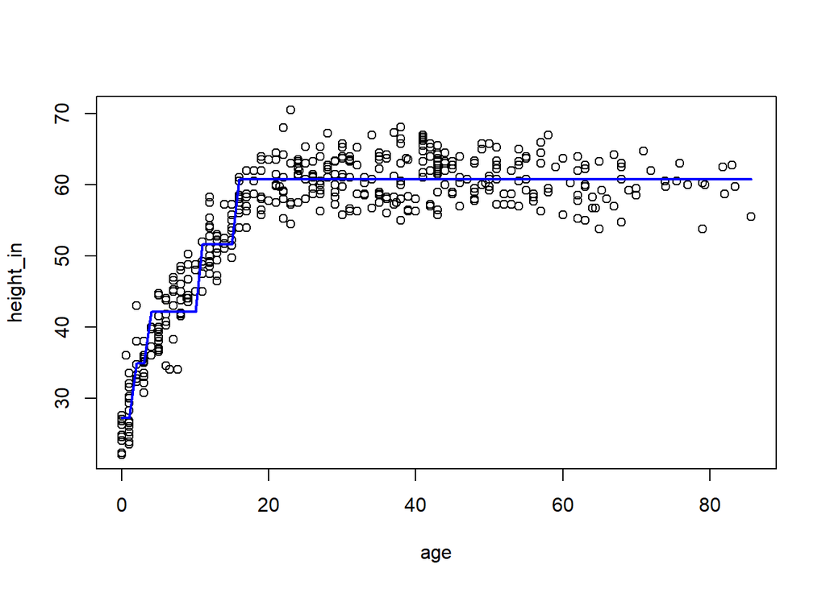

```r
# Sort data so lines function works later
body_train = body_train[order(body_train$age), ]

# Let's model height as a function of age.
fit1 = rpart(height_in ~ age, data = body_train)

with(body_train, plot(age, height_in))
lines(body_train$age, predict(fit1), col = "blue", lwd = 2)
```

We can include additional input variables in the same way as in a `lm` or `glm` command:

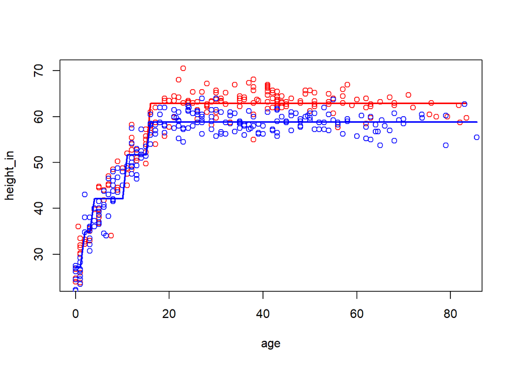

```r
fit2 = rpart(height_in ~ age + sex, data = body_train)

male = body_train$sex == "male"

with(body_train[male, ], plot(age, height_in, col = "red"))
lines(body_train$age[male], predict(fit2)[male], col = "red", lwd = 2)
with(body_train[!male, ], points(age, height_in, col = "blue"))
lines(body_train$age[!male], predict(fit2)[!male], col = "blue", lwd = 2)
```

```r
# * does all possible first order and interaction terms
fit3 = lm(height_in ~ age*sex, data = body_train)

# : does exactly one interaction effect
fit4 = lm(height_in ~ age:sex, data = body_train)
```

Which model is best? Let’s examine how each performs using the test data that we held back from model creation.

```r
models2 = list(fit1, fit2, fit3, fit4)
names(models2) = c("rpart age", "rpart age sex", "lm age*sex", "lm age:sex")

# Apply to all the models:
lapply(models2, mse, body_test, body_test$height_in)
```

```
## $`rpart age`
## [1] 11.75447
##
## $`rpart age sex`
## [1] 8.428809
##
## $`lm age*sex`
## [1] 59.9885
##
## $`lm age:sex`
## [1] 59.42185
```

### On Your Own

Use the `Titanic` dataset (a slightly simplified version of the other Titantic data we worked with) to build several models. We want to predict survival. Which model is best?

To do:

- Create `test` and `train` datasets.
- Create four models: two logistic regression models (see Lab 12) and two RPart models (mess around with the tuning parameters).
- Use your training data to test the models and examine their mean squared error.

```r
data(Titanic)
```

## Cross Validation

An approach called *cross validation* generalizes the idea of splitting the data into a test and a training dataset:

1. Divide the data into $s$ groups, $g_1$, $g_2$, $\dots$, $g_s$, each of size $s/n$.
2. For each group separately, fit a model on the full data *except for the data in group $i$*.
3. Determine the error for each group, using $g_i$ at the testing data for the $i$th model.
4. The model error is the *mean* of the group errors.

This allows us to use more of our data for the training sample. For data sets that aren’t too large, we often let $s=n$. This is called “leave-one-out” cross validation.

Lucky for us, this is built into the RPart package! Using cross-validation, `rpart` will examine a variety of trees using `age` and `sex` to predict `height_in`.

```r
fit5 <- rpart(height_in ~ age + sex, data = body,
              control = rpart.control(xval = nrow(body), minbucket = 2, cp = 0))
printcp(fit5)
```

```
##
## Regression tree:
## rpart(formula = height_in ~ age + sex, data = body, control = rpart.control(xval = nrow(body),
##     minbucket = 2, cp = 0))
##
## Variables actually used in tree construction:
## [1] age sex
##
## Root node error: 64125/544 = 117.88
##
## n= 544
##
##            CP nsplit rel error   xerror      xstd
## 1  7.7722e-01      0  1.000000 1.003687 0.0693006
## 2  7.3546e-02      1  0.222782 0.225099 0.0153530
```

[output cut: 89 more lines]

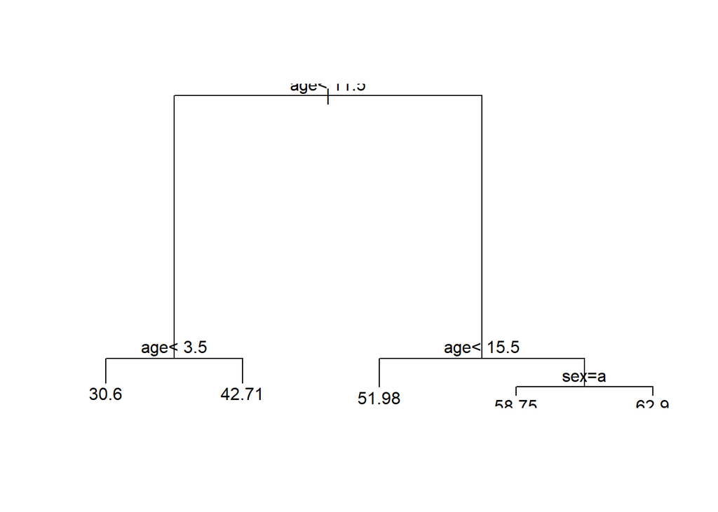

```r
# "prune" the tree so that splits (branches) must decrease overall lack of fit by 0.02
# in the original call, splits did not have to decrease lack of fit at all
fit6 <- prune(fit5, cp=0.02)
plot(fit6); text(fit6) # plot the tree
```

```r
printcp(fit6)
```

```
##
## Regression tree:
## rpart(formula = height_in ~ age + sex, data = body, control = rpart.control(xval = nrow(body),
##     minbucket = 2, cp = 0))
##
## Variables actually used in tree construction:
## [1] age sex
##
## Root node error: 64125/544 = 117.88
##
## n= 544
##
##         CP nsplit rel error   xerror      xstd
## 1 0.777218      0  1.000000 1.003687 0.0693006
## 2 0.073546      1  0.222782 0.225099 0.0153530
## 3 0.043648      2  0.149236 0.151115 0.0096373
## 4 0.024864      3  0.105588 0.108602 0.0063549
## 5 0.020000      4  0.080723 0.083725 0.0060437
```

Let’s examine the MSE for all our models.

```r
models3 = list(fit1, fit2, fit3, fit4, fit5, fit6)
names(models3) = c("rpart age", "rpart age sex", "lm age*sex", "lm age:sex", "cv.all", "cv.fin")

# Apply to all the models:
lapply(models3, mse, body_test, body_test$height_in)
```

```
## $`rpart age`
## [1] 11.75447
##
## $`rpart age sex`
## [1] 8.428809
##
## $`lm age*sex`
## [1] 59.9885
##
## $`lm age:sex`
## [1] 59.42185
##
## $cv.all
## [1] 4.336
##
## $cv.fin
## [1] 8.526544
```